# Final Project Part 3

Feng Wang

October 27, 2016

```r
library('rattle')
library('fpc')
data(wine, package="rattle")
```

# 1. Algorithm and function

## Main function

```r
K_means = function(X, k){
  # group function compute for each data should belong to which cluster
    # compute the distance between data with each means
    group = function(mu, X, n){
    r = rep(0,n)
    for(i in 1:n){r[i] = which.min(rowSums(sweep(mu, 2, X[i,], "-") ^ 2))}
    return(r)
  }
  # j functions compute given means and assigned cluster, the objection function
  # clusting error
  J = function(X, mu, n, r){
    s = 0
    for(i in 1:n){s = s + sum((X[i,] - mu[r[i],])^2)}
    return(s)
  }
  # mu_adj function compute each cluster means
  mu_adj = function(r, X ,k){
    mu = matrix(0, k, dim(X)[2])
    for(i in 1:k){
      mu[i,] = ((r == i) * 1) %*% X / sum(r == i)
    }
    return(mu)
  }
  # Main function
  # Compute the first two steps
  n = dim(X)[1]; mu_start = X[1:k,]
  r_start=group(mu_start,X,n)
  Iter=0
  j_dm=J(X,mu_start,n,r_start)
  mu=mu_adj(r_start,X,k)
  Iter=1
  j_dm = c(j_dm,J(X,mu,n,r_start))
  r=group(mu,X,n)
  Iter = 2

  # Use the while loops to do the K-means, and stop when J keeps the same
  while(abs(j_dm[Iter]-j_dm[Iter-1])!=0){
      mu=mu_adj(r,X,k)
      Iter=Iter+1
      j_dm=c(j_dm,J(X,mu,n,r))

      r=group(mu,X,n)
      Iter=Iter+1
      j_dm=c(j_dm,J(X,mu,n,r))
  }
  return(r)
}
```

# 2. Wine data

## Train data without scale

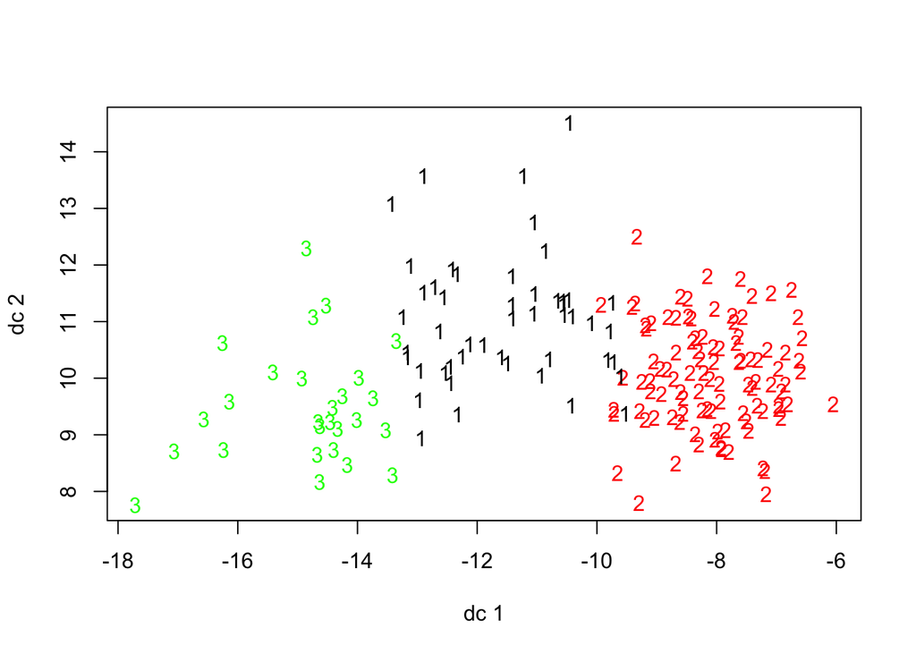

```r
data.train = data.matrix(wine[-1]); k = 3
r1 = K_means(data.train,k)
plotcluster(data.train,r1)
```

It seems that the data has been separated, but the boundares of these three clusters are not clear.
Now we bring another quantify called “accuracy” to test the clustering efficiency.
$$Accuracy = \frac{correct}{n}$$

```r
Accuracy = sum(r1 == wine[1])/length(r1)
print(paste("the Accuracy for non-scale data is ", Accuracy))
```

```
## [1] "the Accuracy for non-scale data is  0.533707865168539"
```

We find the accuracy for the data without scale is slightly greater than 50%, and it meets our observation that the boundary is blured.

## Train data with scale

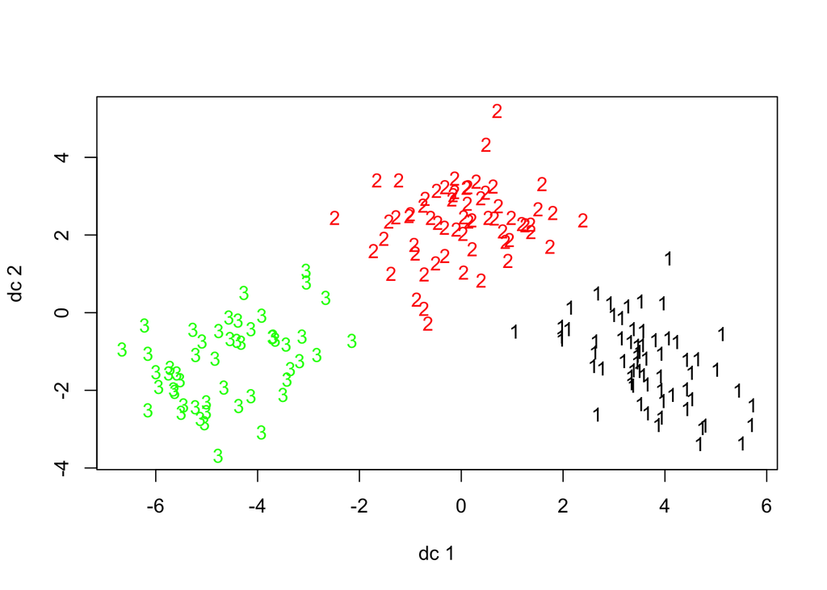

```r
data.train = scale(wine[-1])
r2 = K_means(data.train,k)
plotcluster(data.train,r2)
```

```r
Accuracy = sum(r2 == wine[1])/length(r2)
print(paste("the Accuracy for scale data is ", Accuracy))
```

```
## [1] "the Accuracy for scale data is  0.955056179775281"
```

The scale data has a highly accuracy (>90%) after the clustering, and three clusters in the graph also separate thoroughly.  
The reason is that for the non-scale data, some variable may much larger than the others, and it will dominate the error when doing the K-means. But this problem could be solved using scale data.